# Representating data on maps in R

There are many ways to draw maps and show data on maps in R. In this computer lab, we will cover some of the packages available, but keep in mind that many more tools are available and new packages are released regularly.

## Case study: COVID-19 cases in the US.

For this example, we are using real data compiled by the New York Times and available on their github repository at: https://github.com/nytimes/covid-19-data

Download from the github repository given above the following files into a **data/NYT** subfolder: **us.csv**, **us-states.csv**, **us-counties.csv**. You can open these files (I would recommend opening **us.csv** as it is the smallest file) using a text editor (such as Notepad in windows) and then with Excel (or LibreOffice).

We will now load this file in R:

```r
setwd("C:/lab/MSSTATE/Class/CMB8013/R")

t = read.csv("data/NYT/us.csv")
head(t)
```

```
##         date cases deaths
## 1 2020-01-21     1      0
## 2 2020-01-22     1      0
## 3 2020-01-23     1      0
## 4 2020-01-24     2      0
## 5 2020-01-25     3      0
## 6 2020-01-26     5      0
```

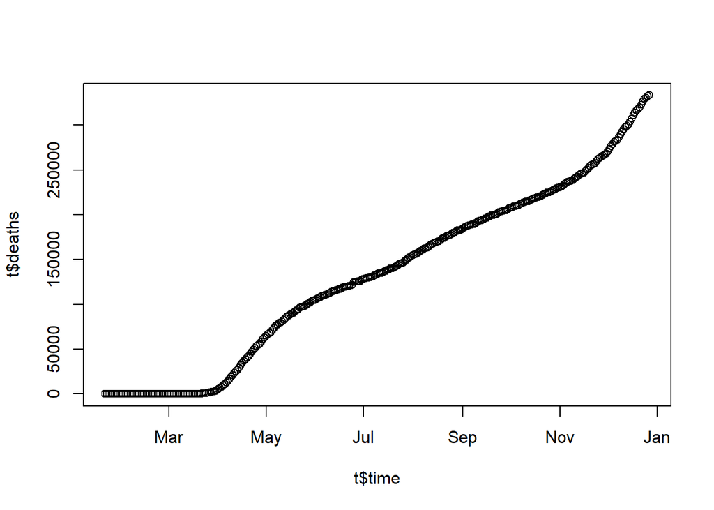

```r
t$time = as.Date(t$date)
plot(t$deaths~t$time)
```

Now, let’s have a look at the file containing the information per state since the beginning of the pandemic (January 2020):

```r
ts = read.csv("data/NYT/us-states.csv")
ts$Date = as.Date(ts$date)
head(ts)
```

```
##         date      state fips cases deaths       Date
## 1 2020-01-21 Washington   53     1      0 2020-01-21
## 2 2020-01-22 Washington   53     1      0 2020-01-22
## 3 2020-01-23 Washington   53     1      0 2020-01-23
## 4 2020-01-24   Illinois   17     1      0 2020-01-24
## 5 2020-01-24 Washington   53     1      0 2020-01-24
## 6 2020-01-25 California    6     1      0 2020-01-25
```

We also need information about states population to compute rates per capita. This information is in the file: data/NYT/states-population.csv

```r
tps = read.csv("data/NYT/states-population.csv")

ts = ts[which(is.element(ts$state, tps$state)==T) , ] # Keeping only states for which we have data on the population (--> removing territories)
```

Look up the documentation for the function **merge** and use it to merge the COVID (ts) and population (tps) data frames.  
Then, you can compute the COVID death rate with the following formula:

```r
tms$deathRate = tms$deaths / tms$population
```

### Drawing maps

We will now represent this data on maps. To do so, you will need to install the following packages: **usmap**, **ggplot2**, **animation**, **magick**

Let’s start with a simple map of the US, and then a simple map of the counties in Mississippi and Alabama:

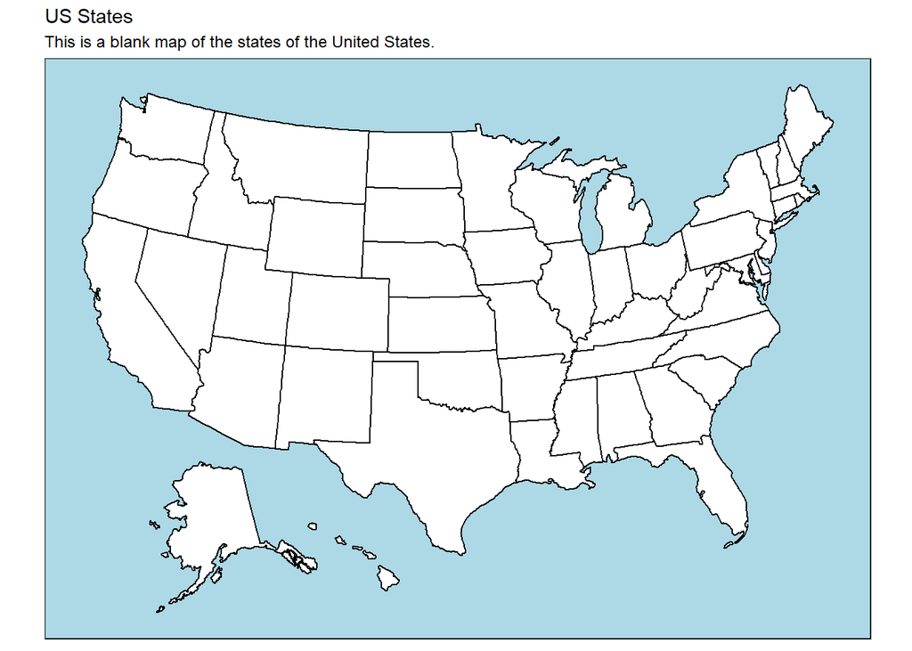

```r
library(usmap)
library(ggplot2)
library(animation)
library(magick)
plot_usmap(regions = "states") +
  labs(title = "US States",
       subtitle = "This is a blank map of the states of the United States.") +
  theme(panel.background = element_rect(color = "black", fill = "lightblue"))
```

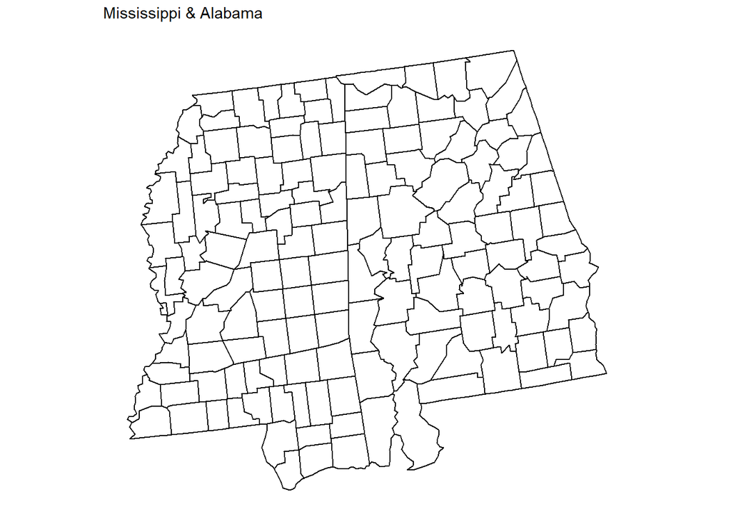

```r
plot_usmap(regions="counties", include = c("MS", "AL") ) +
  labs(title = "Mississippi & Alabama")
```

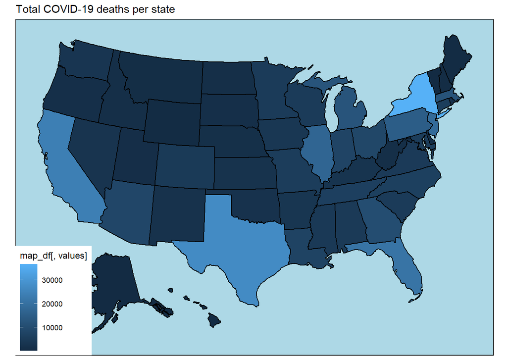

```r
tmp = ts[which(ts$date == "2020-12-25") , ]
plot_usmap(regions = "states", data = tmp, value="deaths") +
  labs(title = "Total COVID-19 deaths per state") +
  theme(panel.background = element_rect(color = "black", fill = "lightblue"))
```

As you can see, the system automatically chose a blue gradient to represent the data on the map. Let’s see how we can customize this.

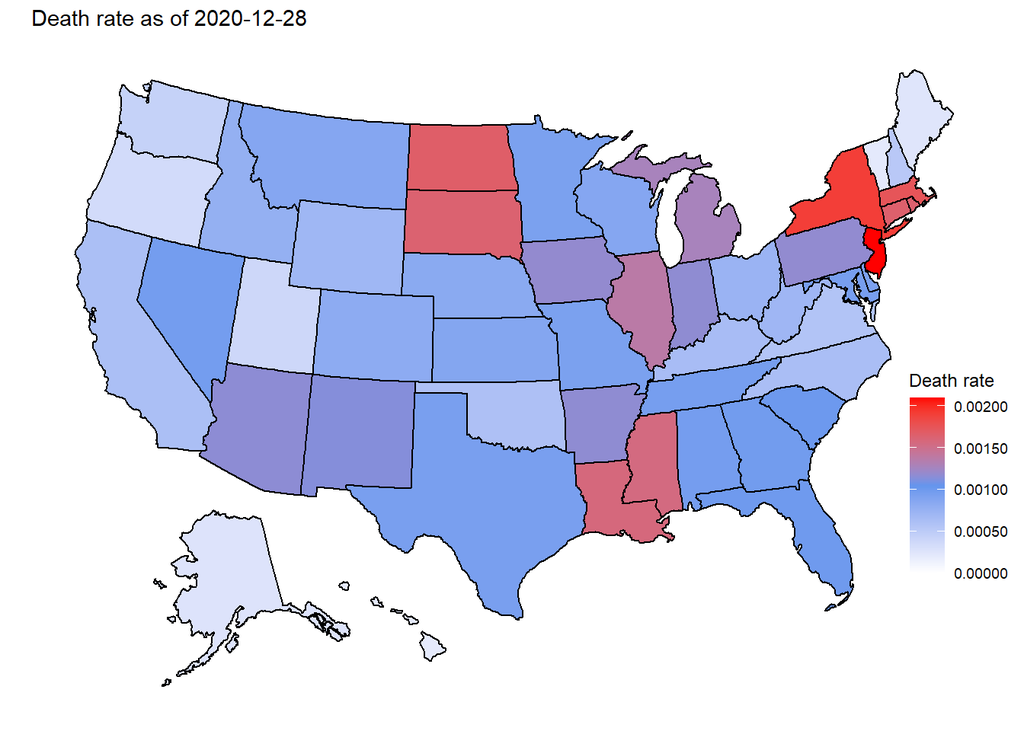

```r
plotDeathRateAtDate <- function(t, myDate, minRate, maxRate, plotMap=F, myRegions=c("state", "counties")[1], includeStates = c()){
  tmp = t[which(t$date==myDate) , ]
  myTitle = paste("Death rate as of ", tmp$date[1], sep="")

  myInclude = unique(tmp$state)
  if( length(includeStates)>0 ){
    myInclude = includeStates
  }

  myMap <- plot_usmap(regions=myRegions, include=myInclude, data=tmp, value="deathRate") + labs(title = myTitle) +
    scale_fill_gradient2( low = "white", mid="cornflowerblue", high = "red",
                          #midpoint = median(tmp$deathRate), na.value="white",
                          midpoint = mean(c(minRate, maxRate)), na.value="white",
                          name = "Death rate",
                          label = scales::comma,
                          limits = c(minRate, maxRate) ) +
    theme(legend.position = c(0.9,0.2))
  if( plotMap==T ){ plot(myMap) }

  myMap
}

minRate = 0
maxRate = max(tms$deathRate, na.rm=T)

vStates = unique(tms$state)
myMap = plotDeathRateAtDate(tms, max(tms$date), minRate, maxRate, F, myRegions="states", includeStates = vStates)
plot(myMap)
```

We now have all the tools in hand to use the function **saveHTML** from the **animation** package and generate an animated map show the progression of COVID-19 across the US. The result should look like this:

[interactive chart not shown]

And we can do the same specifically for Mississippi (with details at the county level):

[interactive chart not shown]

For the curious students who want to see the code used for the county-level data,here are the details. First, you will need to download the file with population estimates per county here: data/NYT/co-est2019-alldata.csv

```r
tcs = read.csv("./data/NYT/us-counties.csv")
tcp = read.csv("data/NYT/co-est2019-alldata.csv")

tcs$date = as.Date(tcs$date) # Making sure the dates are in a format that R can understand.

tcp$fips = tcp$STATE*1000 + tcp$COUNTY # The FIPS is the unique identifier per county. The FIPS number for all counties of a given state start by the same number (which is the FIPS number for that state)

tcm = merge(tcs, tcp, by="fips") # Merging the COVID data with the population data
tcm$deathRate = tcm$deaths/tcm$POPESTIMATE2019 # Computing the death rate

# The "tcm" data frame is now ready to be used for any downstream analysis/plot.
```

## Exercise (graded):

Write a function that computes the increase/decrease in COVID-19 death rate between two dates. Make it as generic as possible, so that it could work on states or counties, or any data.frame that is given as an argument. After you have this function, generate a plot of the COVID-19 difference in death rate from October 1st and November 1st 2020.

Your function should take the following arguments:

- A data frame (containing the data)
- The name of the columns containing (so that the function can work, no matter what the column names are):
  - the date
  - state name or county FIPS
  - the death rate values
- start and end dates

Here is what a call to this function should look like, and the corresponding result:

```r
tdelta = getDeltaRate(tms, as.Date("2020-10-01"), as.Date("2020-11-01"), "Date", "deathRate", "state")
head(tdelta)
```

```
##        state    startRate      endRate    deltaRate
## 1    Alabama 5.196622e-04 0.0006063406 8.667835e-05
## 2     Alaska 7.244941e-05 0.0001066237 3.417425e-05
## 3    Arizona 7.795330e-04 0.0008217107 4.217776e-05
## 4   Arkansas 4.586084e-04 0.0006488116 1.902032e-04
## 5 California 4.046596e-04 0.0004472287 4.256911e-05
## 6   Colorado 3.584120e-04 0.0004014770 4.306501e-05
```

And the corresponding map:

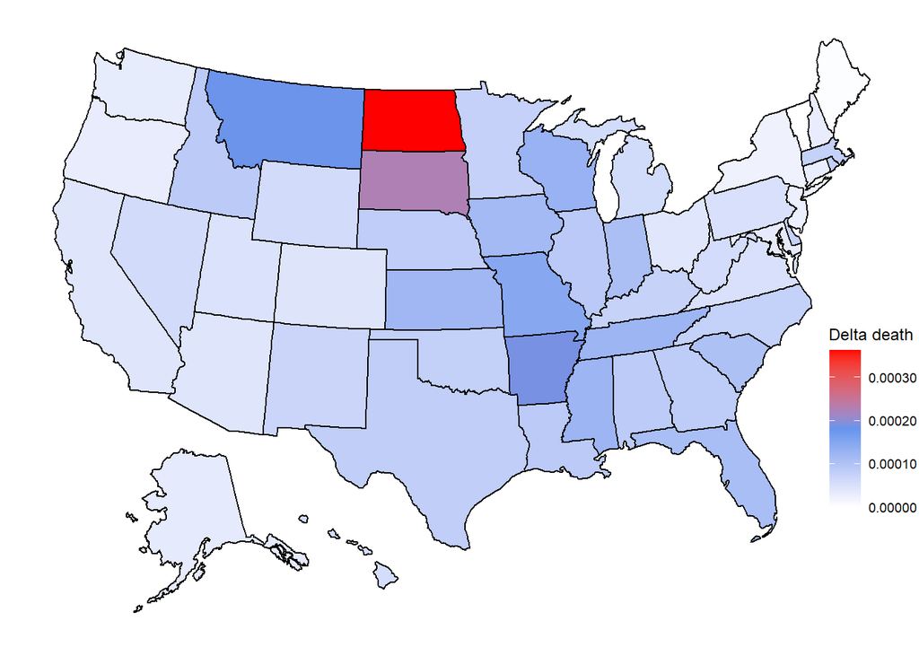

Here is a recipie about how to write the function:

- Make two data frames (tmp1 amd tmp2), one containing the subset of lines from the main data.frame for the starting date, the other will contain the subset of lines for the end date.
- Merge the two sub data frames.
- Compute the delta rate
- Return the merged data frame with the delta rate calculation in one of its column (named **deltaRate**)

As usual, there are many other ways to write a function doing the same job. You could use a for loop and compute the delta rate state by state (or county by county) for example.

Here is the call to the function for data at the county level: (note that correctly plotting the data at the county level requires going through a few more hoops than the state-level data)

```r
tdelta = getDeltaRate(tcm, as.Date("2020-10-01"), as.Date("2020-11-01"), "date", "deathRate", "fips")
head(tdelta)
```

```
##   fips    startRate      endRate    deltaRate
## 1 1001 0.0005011724 0.0005548694 5.369704e-05
## 2 1003 0.0002374190 0.0003180519 8.063288e-05
## 3 1005 0.0002835615 0.0003645791 8.101758e-05
## 4 1007 0.0004465482 0.0006698223 2.232741e-04
## 5 1009 0.0002593989 0.0004323315 1.729326e-04
## 6 1011 0.0015840016 0.0016830017 9.900010e-05
```

And the corresponding result ploted for the states of Mississippi and Louisiana:

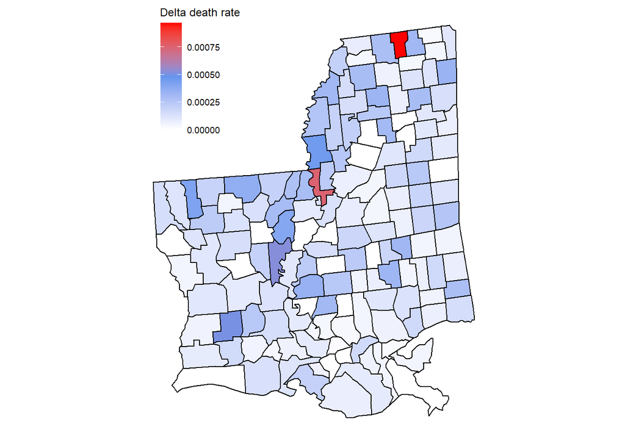

### Going the extra mile (optional / not graded)

Use the function **saveHTML** from the **animate** package to generate an animated map showing the evolution of COVID-19 rate tendency throughout the year 2020.

Looking for another optional exercise? Write a function that computes the death rate per state from the county-level data.

END OF THIS ROADMAP.